# ATUS Sequence Analysis - Optimal Matching

June 27 2020

```r
library(tidyverse)
library(pander)
library(dendextend)
library(NbClust)
library(stringdist)
library(kableExtra)
options(mc.cores = parallel::detectCores())
set.seed(44)
theme_set(theme_custom())

atus <- read_tsv('Data/atus.tsv')
demographics <- read_tsv('Data/demographic.tsv')
demographics <- demographics %>%
  mutate(has_child = as.numeric(n_child > 0)) %>%
  select(-c('age_youngest', 'n_child', 'state'))
```

# The data

- The data comes from the American Time Use Survey diary dataset
- It only includes weekdays and non-holidays
- It contains ~100k individuals
- Each individuals’ day is accounted for in 30 minute periods from 4am-4am the next day. The 30 minute periods were simplified from a diary; where there were conflicts during a given 30 minute period, the most frequent activity (by length of time) was used.
- The activities were simplified from the most detailed selection of 465 options to 15 options:

| Activity |
| --- |
| Sports, Exercise, and Recreation |
| Personal Care |
| Sleep |
| Socializing, Relaxing, and Leisure |
| Household Activities |
| Work |
| Eating and Drinking |
| Professional & Personal Care Services |
| Caring For Household Member |
| Consumer Purchases |
| Other |
| Caring For Nonhousehold Members |
| Education |
| Volunteer |
| Religious and Spiritual |

# Reformating the data into strings

The data needs to be converted from long format where each row repsents an individual’s 30 minute period to dataset where each row represents an individual’s entire day. These requires collapsing the periods into a single string where each character represents an activity.

| Activity | String |
| --- | --- |
| Sports, Exercise, and Recreation | A |
| Personal Care | B |
| Sleep | C |
| Socializing, Relaxing, and Leisure | D |
| Household Activities | E |
| Work | F |
| Eating and Drinking | G |
| Professional & Personal Care Services | H |
| Caring For Household Member | I |
| Consumer Purchases | J |
| Other | K |
| Caring For Nonhousehold Members | L |
| Education | M |
| Volunteer | N |
| Religious and Spiritual | O |

And the resulting dataset:

| ID | String |
| --- | --- |
| 20030100013280 | AABCCCCCCCCCCCCCCCCCCCCDDDDDDDDDDDCCCCCCCCCAAAAA |
| 20030100013848 | CCCCCCCCCCCCEEFFFFFEEEEEECCEGDDDDDDDDDBCCCCCCCCC |
| 20030100014165 | CCBFFFFFFFFFFFFFFFHGAABIEEGGGIIIDDIFFCCCCCCCCCCC |
| 20030100014169 | CCCCCCCCCIIIIDDEEGDDCCCDIIIEGDDDIBDDDCCCCCCCCCCC |
| 20030100014209 | CCCCCBFFFFGEFFFFFFFFFFGEFFFIJJGGGIICCCCCCCCCCCCC |
| 20030100014427 | CCBBBFFFFFFFFFFFDFFFFFFFGDDDDDDDDKDCCCCCCCCCCCCC |

# Calculating the distance matrix

1. Sample from the dataset for computational efficiency
2. Calculate the distance matrix using string distance
- Will first using Hamming distance (substitutions only)

```r
# sample nrows from the dataset using the survey weights
weights <- demographics %>% right_join(atus_string, by = "ID") %>% pull(survey_weight)
atus_string_samp <- sample_n(atus_string, size = 5000, weight = weights, replace = TRUE)
```

```r
# compute the string distances
# dist_matrix <- stringdistmatrix(a = atus_string_samp$string, method = "osa")
dist_matrix <- stringdistmatrix(a = atus_string_samp$string, method = "hamming")
# dist_matrix <- stringdistmatrix(a = atus_string_samp$string, method = "lcs")

# top code infinite values
# hist(dist_matrix)
dist_matrix[is.infinite(dist_matrix)] <- 10000
```

The distance matrix appears to be 1-dimensional with length equal to 12,497,500 which is n * (n - 1) / 2

```
##  'dist' num [1:12497500] 38 32 16 34 19 36 22 32 36 30 ...
##  - attr(*, "Size")= int 5000
##  - attr(*, "Diag")= logi FALSE
##  - attr(*, "Upper")= logi FALSE
##  - attr(*, "method")= chr "hamming"
```

# Determining optimal clusters

Determine the optimum number of clusters using silhouette width

```r
# get optimal cluster sizes
hcl_ch <- NbClust(
  data = NULL,
  diss = dist_matrix,
  distance = NULL,
  method = 'ward.D2',
  max.nc = 10,
  min.nc = 4,
  index = 'silhouette'
)
```

```
##
##  Only frey, mcclain, cindex, sihouette and dunn can be computed. To compute the other indices, data matrix is needed
```

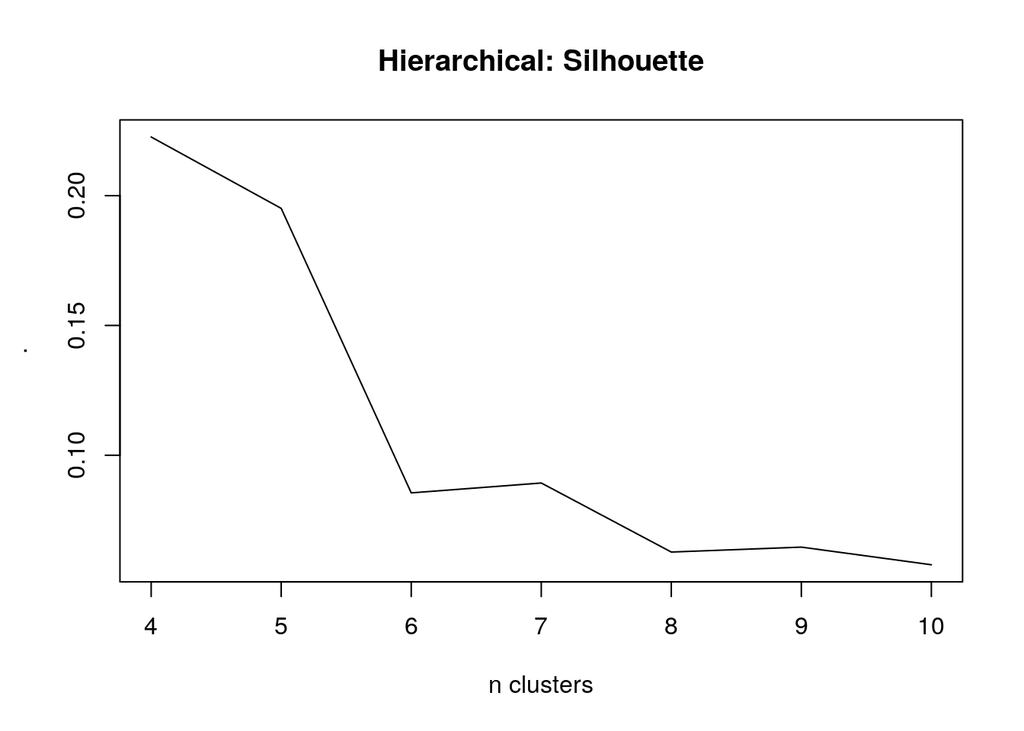

```r
hcl_ch$All.index %>% plot(type = 'l', x = 4:10, main = 'Hierarchical: Silhouette', xlab = 'n clusters')
```

# Re-cluster using a larger sample

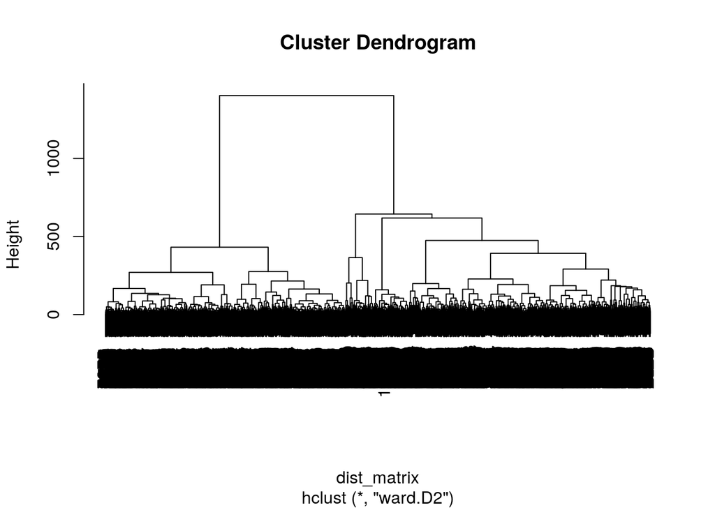

```r
# increase sample size
n_sample <- 10000
atus_string_samp <- sample_n(atus_string, size = n_sample, weight = weights, replace = TRUE)

# compute the string distances
dist_matrix <- stringdistmatrix(a = atus_string_samp$string, method = "hamming")
# dist_matrix <- stringdistmatrix(a = atus_string_samp$string, method = "lcs")

# ward (D2) linkage hier clustering
hcl_ward <- hclust(d = dist_matrix, method = 'ward.D2')
plot(hcl_ward)
```

# Examine the activities by cluster

The cluster results can be examined through sequence plots where the x-axis represents the time of day, the y-axis the individuals, and the fill color the activity.

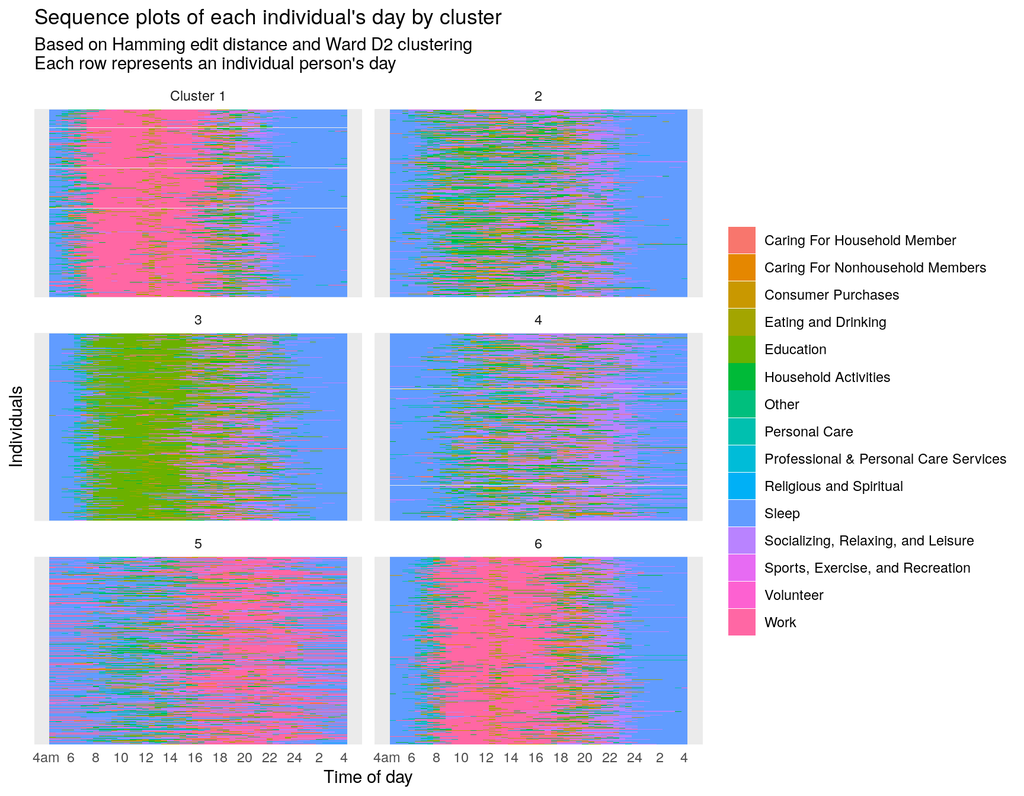

Another method is to view the same data but computing the proportion of individuals participating in a given activity for a given time period.

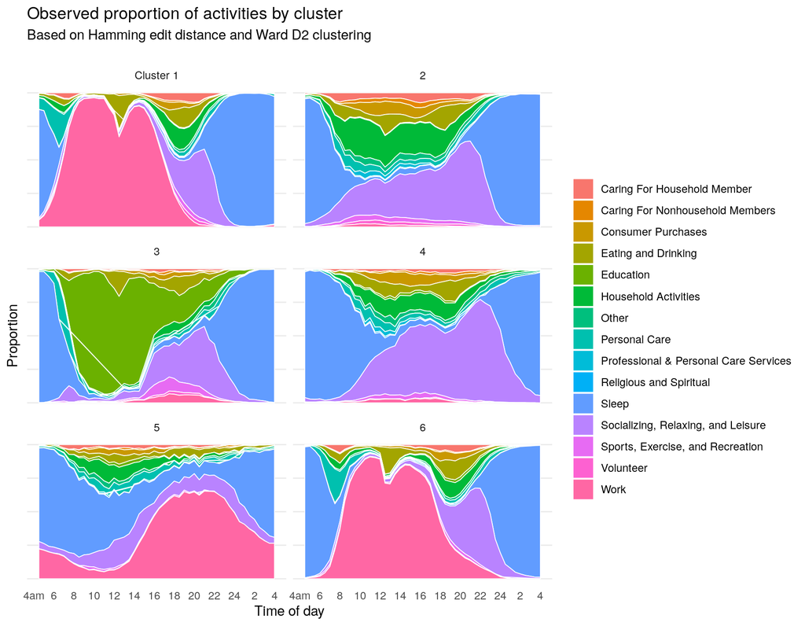

# Examine the demographics by cluster

Tying back the data to the original respondents and their demographic data, we can see how they differ by cluster. For example, cluster 3 skews heavily to younger individuals – which matches well to cluster 3’s most defining activity: education.

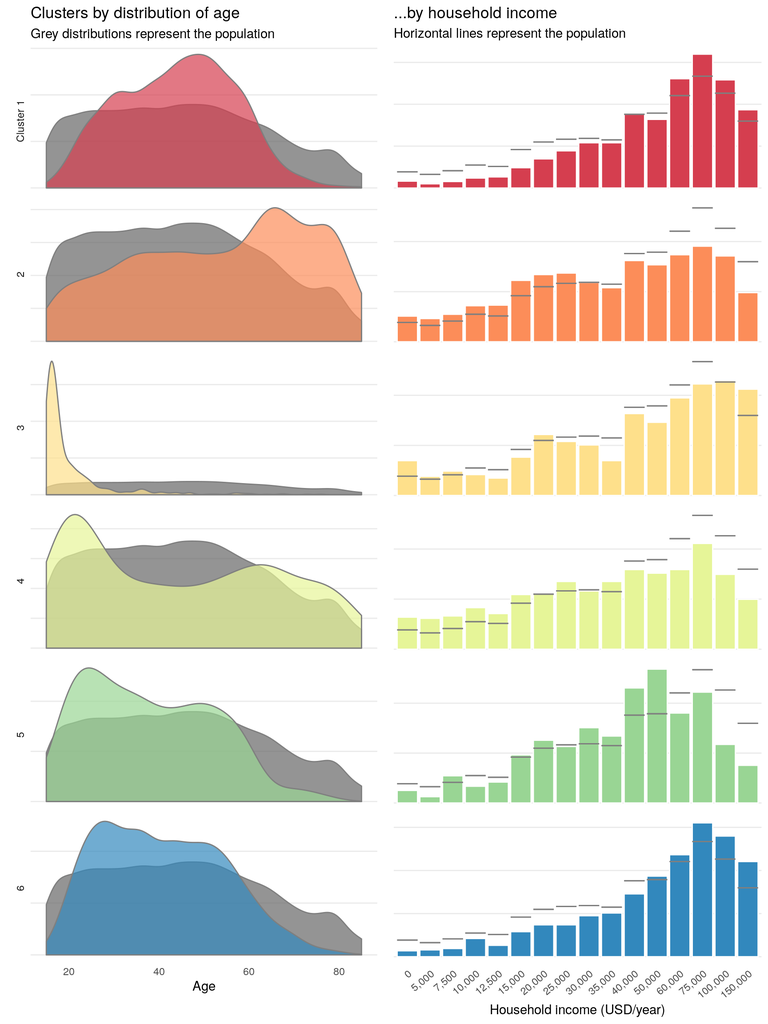

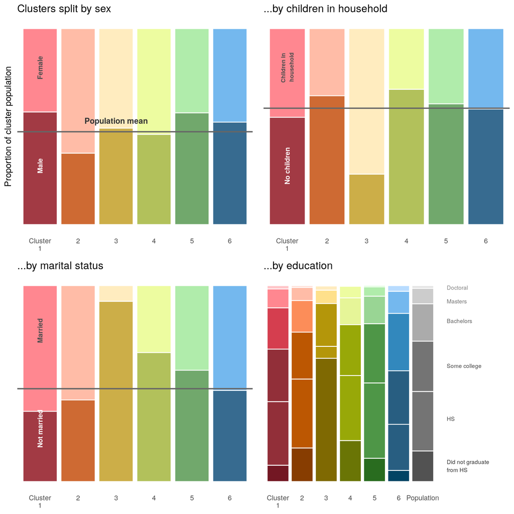

# Repeat the clustering using LCS (insertions, deletions only)

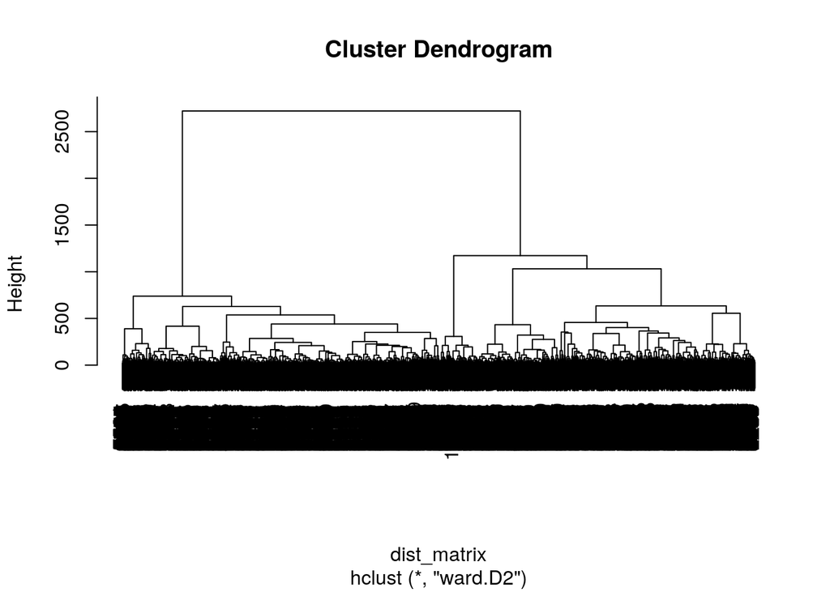

```r
# increase sample size
n_sample <- 10000
atus_string_samp <- sample_n(atus_string, size = n_sample, weight = weights, replace = TRUE)

# compute the string distances
# dist_matrix <- stringdistmatrix(a = atus_string_samp$string, method = "hamming")
dist_matrix <- stringdistmatrix(a = atus_string_samp$string, method = "lcs")

# ward (D2) linkage hier clustering
hcl_ward <- hclust(d = dist_matrix, method = 'ward.D2')
plot(hcl_ward)
```

# Examine the activities by cluster

[figure not shown]

[figure not shown]

# Examine the demographics by cluster

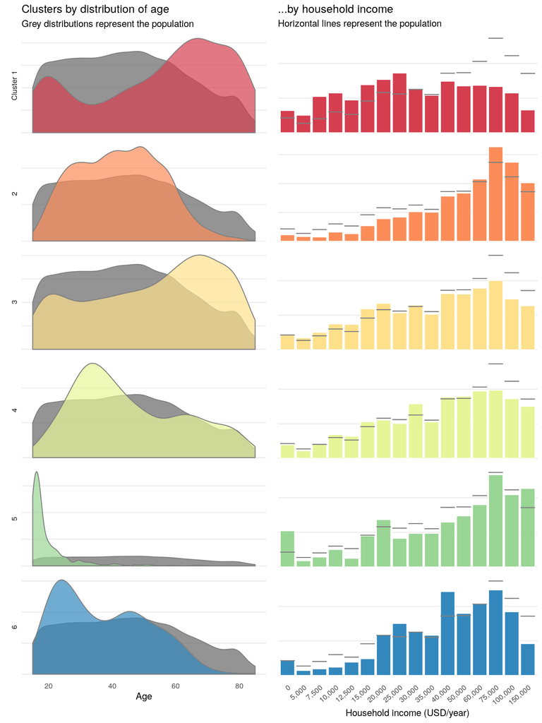

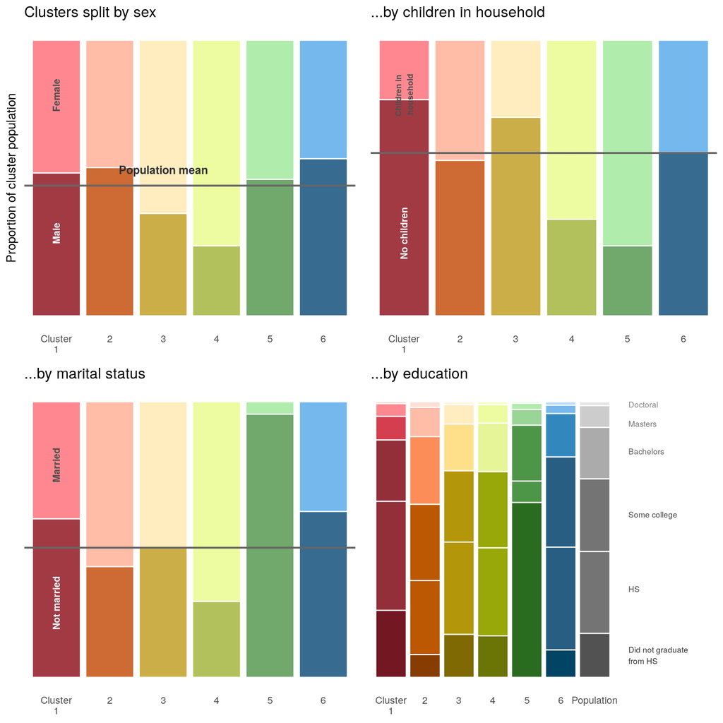